# How many bikes will Washington rent tomorrow?

Every hour of 2011 and 2012 from Washington D.C.'s Capital Bikeshare system: **17,379 hours and 3.3 million rentals**. The task is a classic one for any operations team that has to place bikes and staff in advance: **forecast the demand of every hour of tomorrow**, given what is known at midnight.

What makes it a real forecasting problem and not a plain regression:

- the model may only use **information available at the time** (yesterday's demand, not today's), and it is judged on the **last six months of 2012, which it never saw**;
- the system grew by about 65% between the two years, which models that average the past cannot follow;
- a good forecast also says **how uncertain** it is, so the notebook builds an 80% prediction interval and checks that it really contains 80% of the outcomes;
- and then it looks at *where it fails*: Hurricane Sandy hits the test period.

**Data:** [Bike Sharing Dataset](https://archive.ics.uci.edu/dataset/275/bike+sharing+dataset) from the UCI Machine Learning Repository (Fanaee-T and Gama, 2013; CC BY 4.0). The notebook downloads it (about 0.3 MB) into `BIKE_DIR` on the first run.

```python
import io
import os
import urllib.request
import zipfile
from pathlib import Path

import matplotlib.pyplot as plt
import numpy as np
import pandas as pd
from sklearn.ensemble import HistGradientBoostingRegressor
from sklearn.inspection import permutation_importance

DATA_DIR = Path(os.environ.get("BIKE_DIR", "bike_data"))
DATA_DIR.mkdir(exist_ok=True)
AMBER, BLUE, GREY = "#e8a33d", "#2b6cb0", "#a0aec0"
plt.rcParams.update({"axes.spines.top": False, "axes.spines.right": False, "axes.grid": True,
                     "grid.alpha": 0.25, "figure.dpi": 110})
```

## 1. Load and clean the hourly data

The file has one row per hour *with rentals*, so 165 hours are missing (mostly in the small hours). Those are treated as **zero rentals** and the weather is carried forward. The weather columns come normalised, so they are converted back to degrees Celsius, percent humidity and km/h wind.

```python
zip_path = DATA_DIR / "bike_sharing.zip"
if not zip_path.exists():
    urllib.request.urlretrieve("https://archive.ics.uci.edu/static/public/275/bike+sharing+dataset.zip", zip_path)
with zipfile.ZipFile(zip_path) as z:
    raw = pd.read_csv(z.open("hour.csv"), parse_dates=["dteday"])
raw["time"] = raw.dteday + pd.to_timedelta(raw.hr, unit="h")
raw = raw.set_index("time")

full_index = pd.date_range(raw.index.min(), raw.index.max(), freq="h")
missing = full_index.difference(raw.index)
print(f"{len(raw):,} hours in the file, {len(missing)} missing; {np.mean(missing.hour < 6):.0%} of the missing hours are between midnight and 6 a.m.")

d = raw.reindex(full_index)
d[["cnt", "casual", "registered"]] = d[["cnt", "casual", "registered"]].fillna(0)
d[["weathersit", "temp", "atemp", "hum", "windspeed"]] = d[["weathersit", "temp", "atemp", "hum", "windspeed"]].ffill()
d["hour"] = d.index.hour
d["dow"] = d.index.dayofweek
d["month"] = d.index.month
d["holiday"] = d.holiday.fillna(0).astype(int)
d["workingday"] = ((d.dow < 5) & (d.holiday == 0)).astype(int)
d["weather"] = d.weathersit.astype(int)                  # 1 clear, 2 mist, 3 light rain or snow, 4 heavy rain or snow
d["temp_c"] = d.temp * 41
d["feels_c"] = d.atemp * 50
d["humidity"] = d.hum * 100
d["wind"] = d.windspeed * 67
d[["cnt", "temp_c", "humidity", "wind"]].describe().round(1).T
```

```
17,379 hours in the file, 165 missing; 67% of the missing hours are between midnight and 6 a.m.
```

|  | count | mean | std | min | 25% | 50% | 75% | max |
| --- | --- | --- | --- | --- | --- | --- | --- | --- |
| cnt | 17544.0 | 187.7 | 181.5 | 0.0 | 38.0 | 140.0 | 279.0 | 977.0 |
| temp_c | 17544.0 | 20.3 | 7.9 | 0.8 | 13.9 | 20.5 | 27.1 | 41.0 |
| humidity | 17544.0 | 62.9 | 19.3 | 0.0 | 48.0 | 63.0 | 79.0 | 100.0 |
| wind | 17544.0 | 12.8 | 8.3 | 0.0 | 7.0 | 13.0 | 17.0 | 57.0 |

## 2. What drives the demand?

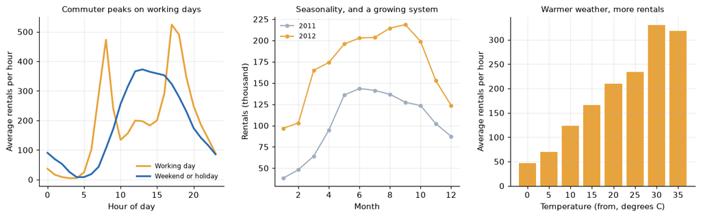

|  | 2011 | 2012 | growth |
| --- | --- | --- | --- |
| rentals | 1243103.0 | 2049576.0 | 0.649 |

```python
fig, axes = plt.subplots(1, 3, figsize=(12, 3.8))

profile = d.groupby(["workingday", "hour"]).cnt.mean().unstack(0)
axes[0].plot(profile.index, profile[1], color=AMBER, lw=2.2, label="Working day")
axes[0].plot(profile.index, profile[0], color=BLUE, lw=2.2, label="Weekend or holiday")
axes[0].set_xlabel("Hour of day")
axes[0].set_ylabel("Average rentals per hour")
axes[0].set_title("Commuter peaks on working days", fontsize=10)
axes[0].legend(frameon=False, fontsize=8)

monthly = d.groupby([d.index.year, d.index.month]).cnt.sum().unstack(0) / 1000
axes[1].plot(monthly.index, monthly[2011], marker="o", ms=4, color=GREY, label="2011")
axes[1].plot(monthly.index, monthly[2012], marker="o", ms=4, color=AMBER, label="2012")
axes[1].set_xlabel("Month")
axes[1].set_ylabel("Rentals (thousand)")
axes[1].set_title("Seasonality, and a growing system", fontsize=10)
axes[1].legend(frameon=False, fontsize=8)

bins = pd.cut(d.temp_c, np.arange(-5, 45, 5))
by_temp = d.groupby(bins, observed=True).cnt.mean()
axes[2].bar([f"{int(i.left)}" for i in by_temp.index], by_temp.values, color=AMBER)
axes[2].set_xlabel("Temperature (from, degrees C)")
axes[2].set_ylabel("Average rentals per hour")
axes[2].set_title("Warmer weather, more rentals", fontsize=10)
fig.tight_layout()
plt.show()
pd.DataFrame({"2011": [d[d.index.year == 2011].cnt.sum()], "2012": [d[d.index.year == 2012].cnt.sum()]},
             index=["rentals"]).assign(growth=lambda x: x["2012"] / x["2011"] - 1).round(3)
```

```python
weather = d.groupby("weather").agg(hours=("cnt", "size"), avg_rentals=("cnt", "mean"), avg_temp=("temp_c", "mean"))
weather.index = weather.index.map({1: "1 clear", 2: "2 mist or cloud", 3: "3 light rain or snow", 4: "4 heavy rain or snow"})
weather.round(1)
```

| weather | hours | avg_rentals | avg_temp |
| --- | --- | --- | --- |
| 1 clear | 11455 | 204.1 | 20.9 |
| 2 mist or cloud | 4563 | 174.4 | 19.4 |
| 3 light rain or snow | 1523 | 104.0 | 18.4 |
| 4 heavy rain or snow | 3 | 74.3 | 7.7 |

## 3. Setting up an honest forecast

**The scenario:** at midnight, predict the 24 hours of the coming day. So for every hour the model may use:

- the calendar (hour, weekday, month, working day, holiday),
- the weather (an actual-weather stand-in for a weather forecast; in practice the forecast would be a little worse),
- and **demand up to the end of yesterday only**: the same hour yesterday, two days ago and a week ago, the average of the same hour over the past seven days, and yesterday's total and last week's daily average, which tell the model how big the system currently is.

**The split by time:** the models are fitted on January 2011 to March 2012, tuned on April to June 2012, and then refitted on everything up to June 2012 and judged on **July to December 2012**.

```python
# demand features that only use the past (nothing from the forecast day itself)
d["lag_24"] = d.cnt.shift(24)
d["lag_48"] = d.cnt.shift(48)
d["lag_168"] = d.cnt.shift(168)
d["same_hour_7d"] = sum(d.cnt.shift(24 * k) for k in range(1, 8)) / 7
daily = d.cnt.resample("D").sum()
d["yesterday_total"] = daily.shift(1).reindex(d.index.normalize()).to_numpy()
d["week_avg_total"] = daily.rolling(7).mean().shift(1).reindex(d.index.normalize()).to_numpy()

CALENDAR_WEATHER = ["hour", "dow", "month", "workingday", "holiday", "weather", "temp_c", "feels_c", "humidity", "wind"]
LAGS = ["lag_24", "lag_48", "lag_168", "same_hour_7d", "yesterday_total", "week_avg_total"]

ready = d.dropna(subset=LAGS).copy()                       # the first week has no history
train = ready[ready.index < "2012-04-01"]
valid = ready[(ready.index >= "2012-04-01") & (ready.index < "2012-07-01")]
train_valid = ready[ready.index < "2012-07-01"]
test = ready[ready.index >= "2012-07-01"]
print(f"train {len(train):,} h | validation {len(valid):,} h | test {len(test):,} h ({test.index.min():%d %b %Y} to {test.index.max():%d %b %Y})")
```

```
train 10,776 h | validation 2,184 h | test 4,416 h (01 Jul 2012 to 31 Dec 2012)
```

## 4. The models

Two simple baselines that any model has to beat, and two gradient-boosted tree models:

- **Same hour last week**: predict that this hour will be like the same hour seven days ago.
- **Weekday x hour average**: for every weekday and hour, the average demand in the training years. It knows the weekly rhythm, but it cannot know the system has grown.
- **Boosted trees, calendar and weather only**: no knowledge of recent demand.
- **Boosted trees with recent demand**: the full feature set above.
- **Boosted trees on demand relative to the recent level**: the same idea, but predicting demand as a *multiple of last week's average* so that a busier season does not push the model beyond the levels it learned (added after the first four models turned out to forecast too little).

Demand is a *count*, so the trees are trained with a Poisson loss, which respects that predictions cannot be negative and that busy hours have more noise.

```python
def score(y, pred):
    err = y - pred
    return {"MAE": np.abs(err).mean(),
            "RMSE": np.sqrt((err ** 2).mean()),
            "WAPE": np.abs(err).sum() / y.sum(),      # share of the demand that was missed
            "bias": pred.sum() / y.sum() - 1}         # negative = the model forecasts too little overall

def fit_gbm(features, frame, **params):
    model = HistGradientBoostingRegressor(loss="poisson", random_state=0, **params)
    return model.fit(frame[features], frame.cnt)

# small grid on the validation months
rows = []
for lr in [0.05, 0.1]:
    for depth in [4, 6, None]:
        for leaves in [15, 31]:
            m = fit_gbm(CALENDAR_WEATHER + LAGS, train, learning_rate=lr, max_depth=depth, max_leaf_nodes=leaves, max_iter=300)
            rows.append({"learning_rate": lr, "max_depth": depth, "max_leaf_nodes": leaves,
                         **score(valid.cnt, m.predict(valid[CALENDAR_WEATHER + LAGS]))})
grid = pd.DataFrame(rows).sort_values("MAE")
best = grid.iloc[0]
PARAMS = dict(learning_rate=float(best.learning_rate), max_depth=None if pd.isna(best.max_depth) else int(best.max_depth),
              max_leaf_nodes=int(best.max_leaf_nodes), max_iter=300)
print("chosen on the validation months:", PARAMS)
grid.head(4).round(2)
```

```
chosen on the validation months: {'learning_rate': 0.1, 'max_depth': 6, 'max_leaf_nodes': 31, 'max_iter': 300}
```

|  | learning_rate | max_depth | max_leaf_nodes | MAE | RMSE | WAPE | bias |
| --- | --- | --- | --- | --- | --- | --- | --- |
| 9 | 0.10 | 6.0 | 31 | 42.76 | 67.03 | 0.16 | -0.02 |
| 3 | 0.05 | 6.0 | 31 | 43.59 | 67.58 | 0.17 | -0.02 |
| 11 | 0.10 | NaN | 31 | 43.84 | 67.79 | 0.17 | -0.03 |
| 7 | 0.10 | 4.0 | 31 | 44.25 | 68.72 | 0.17 | -0.02 |

```python
# refit on everything before the test period and predict July-December 2012
profile = train_valid.groupby(["dow", "hour"]).cnt.mean()
predictions = {
    "Same hour last week": test.lag_168.to_numpy(),
    "Weekday x hour average": profile.reindex(pd.MultiIndex.from_arrays([test.dow, test.hour])).to_numpy(),
}
model_cal = fit_gbm(CALENDAR_WEATHER, train_valid, **PARAMS)
predictions["Trees: calendar + weather"] = model_cal.predict(test[CALENDAR_WEATHER])
model_full = fit_gbm(CALENDAR_WEATHER + LAGS, train_valid, **PARAMS)
predictions["Trees + recent demand"] = model_full.predict(test[CALENDAR_WEATHER + LAGS])

# Trees cannot predict above the demand levels they saw in training, but the system keeps growing. A scale-free version predicts demand
# *relative to the recent level* and multiplies back, so a busier month does not push the features outside what the trees know.
def relative(frame):
    scale = frame.week_avg_total / 24                              # average hourly demand over the past seven days
    rel = frame[CALENDAR_WEATHER].copy()
    for col in ["lag_24", "lag_48", "lag_168", "same_hour_7d"]:
        rel[col + "_rel"] = frame[col] / scale
    rel["yesterday_vs_week"] = frame.yesterday_total / frame.week_avg_total
    return rel, scale

rel_train, scale_train = relative(train_valid)
rel_test, scale_test = relative(test)
model_rel = HistGradientBoostingRegressor(loss="poisson", random_state=0, **PARAMS).fit(
    rel_train, train_valid.cnt / scale_train, sample_weight=scale_train)
predictions["Trees on demand relative to recent level"] = model_rel.predict(rel_test) * scale_test.to_numpy()

results = pd.DataFrame({name: score(test.cnt, p) for name, p in predictions.items()}).T
BEST = results.MAE.idxmin()
print("best model on the unseen months:", BEST)
results.round(3)
```

```
best model on the unseen months: Trees on demand relative to recent level
```

|  | MAE | RMSE | WAPE | bias |
| --- | --- | --- | --- | --- |
| Same hour last week | 65.957 | 114.940 | 0.262 | 0.031 |
| Weekday x hour average | 107.023 | 150.640 | 0.425 | -0.335 |
| Trees: calendar + weather | 93.599 | 131.320 | 0.372 | -0.344 |
| Trees + recent demand | 48.713 | 75.724 | 0.193 | -0.123 |
| Trees on demand relative to recent level | 38.335 | 61.213 | 0.152 | 0.001 |

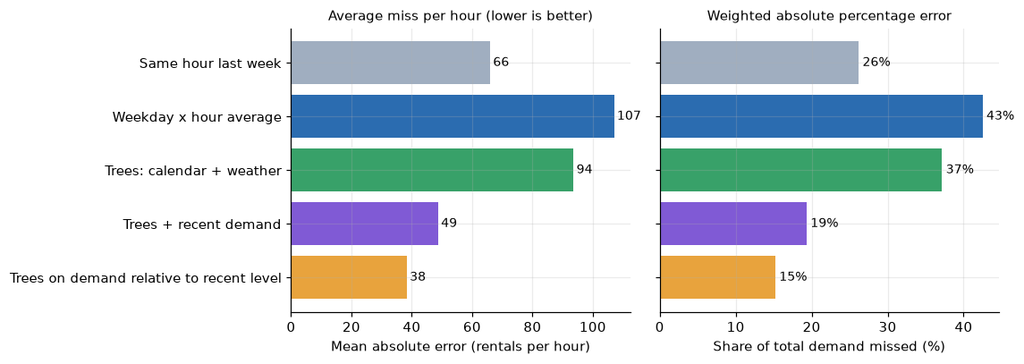

```python
fig, axes = plt.subplots(1, 2, figsize=(10.5, 3.8))
colors = [GREY, BLUE, "#38a169", "#805ad5", AMBER]
axes[0].barh(results.index[::-1], results.MAE[::-1], color=colors[::-1])
for y, v in enumerate(results.MAE[::-1]):
    axes[0].text(v + 1, y, f"{v:.0f}", va="center", fontsize=9)
axes[0].set_xlabel("Mean absolute error (rentals per hour)")
axes[0].set_title("Average miss per hour (lower is better)", fontsize=10)
axes[1].barh(results.index[::-1], results.WAPE[::-1] * 100, color=colors[::-1])
for y, v in enumerate(results.WAPE[::-1] * 100):
    axes[1].text(v + 0.5, y, f"{v:.0f}%", va="center", fontsize=9)
axes[1].set_xlabel("Share of total demand missed (%)")
axes[1].set_title("Weighted absolute percentage error", fontsize=10)
axes[1].set_yticklabels([])
fig.tight_layout()
plt.show()
```

## 5. How sure is the forecast? Prediction intervals

A planner needs a range, not one number. Two more trees are trained with a **quantile loss** to predict the 10th and the 90th percentile of demand, which gives an 80% interval. The check that matters is **coverage**: on the unseen months, did the real demand fall inside the interval about 80% of the time?

The first attempt is honest about a common problem: intervals fitted on the training period are **too narrow** for the future, because the model has seen those hours and the future is always a little different. The fix is **conformal calibration** (conformalised quantile regression): the quantile trees are fitted on the training months only, the validation months measure by how much they miss, and the interval is widened by exactly that amount.

```python
# the quantile trees use the same scale-free set-up as the best point model: they predict a quantile of demand relative to the recent level
def fit_quantile(q, frame):
    rel, scale = relative(frame)
    model = HistGradientBoostingRegressor(loss="quantile", quantile=q, random_state=0, learning_rate=PARAMS["learning_rate"],
                                          max_depth=PARAMS["max_depth"], max_leaf_nodes=PARAMS["max_leaf_nodes"], max_iter=300)
    return model.fit(rel, frame.cnt / scale)

def predict_quantile(model, frame):
    rel, scale = relative(frame)
    return model.predict(rel) * scale.to_numpy()

y_test = test.cnt.to_numpy()

# 1. raw quantile trees, fitted on everything before the test period
raw_lo = predict_quantile(fit_quantile(0.1, train_valid), test)
raw_hi = predict_quantile(fit_quantile(0.9, train_valid), test)

# 2. conformalised: fit on the training months, measure the misses on the validation months, widen by that amount
q_lo, q_hi = fit_quantile(0.1, train), fit_quantile(0.9, train)
yv = valid.cnt.to_numpy()
scores = np.maximum(predict_quantile(q_lo, valid) - yv, yv - predict_quantile(q_hi, valid))
level = min(np.ceil((len(valid) + 1) * 0.8) / len(valid), 1.0)
widen = np.quantile(scores, level, method="higher")
lower = np.maximum(predict_quantile(q_lo, test) - widen, 0)
upper = predict_quantile(q_hi, test) + widen

def coverage(lo, hi):
    return {"coverage": ((y_test >= lo) & (y_test <= hi)).mean(), "average_width": np.mean(hi - lo)}

intervals = pd.DataFrame({"Raw quantile trees": coverage(raw_lo, raw_hi), "Conformalised": coverage(lower, upper)}).T
print(f"the interval is widened by {widen:.0f} rentals on each side")
intervals.round(3)
```

```
the interval is widened by 7 rentals on each side
```

|  | coverage | average_width |
| --- | --- | --- |
| Raw quantile trees | 0.689 | 107.94 |
| Conformalised | 0.800 | 127.58 |

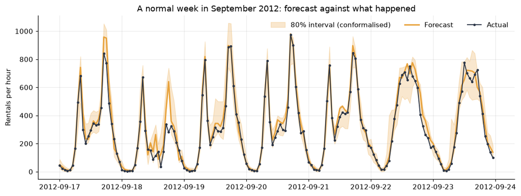

```python
week = slice("2012-09-17", "2012-09-23")
w = test.loc[week]
fig, ax = plt.subplots(figsize=(10.5, 4))
idx = test.index.get_indexer(w.index)
ax.fill_between(w.index, lower[idx], upper[idx], color=AMBER, alpha=0.25, label="80% interval (conformalised)")
ax.plot(w.index, predictions[BEST][idx], color=AMBER, lw=2, label="Forecast")
ax.plot(w.index, w.cnt, color="#2d3748", lw=1.3, marker="o", ms=2.5, label="Actual")
ax.set_ylabel("Rentals per hour")
ax.set_title("A normal week in September 2012: forecast against what happened")
ax.legend(frameon=False, ncol=3)
fig.tight_layout()
plt.show()
```

## 6. Where does it fail?

Averages hide the interesting part. First, the error by hour of the day for the best model against the last-week baseline; then the **days with the biggest misses**.

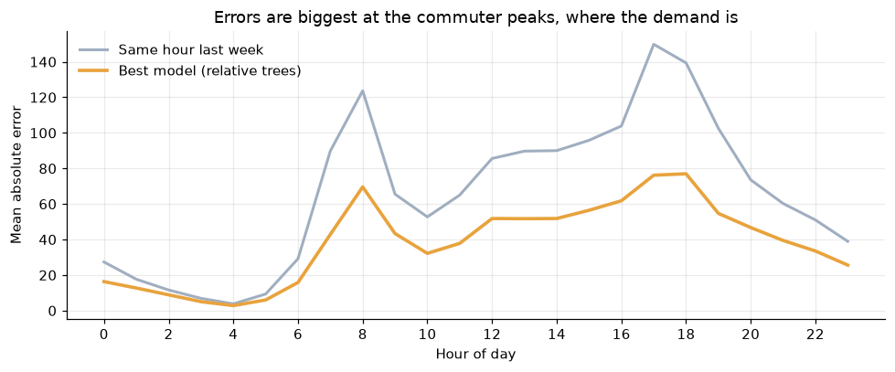

```python
best_pred = predictions[BEST]
by_hour = pd.DataFrame({"hour": test.hour, "model": np.abs(test.cnt - best_pred), "last_week": np.abs(test.cnt - test.lag_168)}).groupby("hour").mean()
fig, ax = plt.subplots(figsize=(9, 3.8))
ax.plot(by_hour.index, by_hour.last_week, color=GREY, lw=2, label="Same hour last week")
ax.plot(by_hour.index, by_hour.model, color=AMBER, lw=2.4, label="Best model (relative trees)")
ax.set_xlabel("Hour of day")
ax.set_ylabel("Mean absolute error")
ax.set_xticks(range(0, 24, 2))
ax.set_title("Errors are biggest at the commuter peaks, where the demand is")
ax.legend(frameon=False)
fig.tight_layout()
plt.show()
```

```python
daily_err = pd.DataFrame({"actual": test.cnt, "forecast": best_pred, "abs_err": np.abs(test.cnt - best_pred),
                          "weather": test.weather, "temp_c": test.temp_c}).resample("D").agg(
    {"actual": "sum", "forecast": "sum", "abs_err": "sum", "weather": "max", "temp_c": "mean"})
daily_err["missed_pct"] = daily_err.abs_err / daily_err.actual * 100
daily_err["holiday"] = test.holiday.resample("D").max().astype(int)
worst = daily_err.sort_values("abs_err", ascending=False).head(6)
worst.assign(actual=worst.actual.round(0), forecast=worst.forecast.round(0), abs_err=worst.abs_err.round(0),
             missed_pct=worst.missed_pct.round(0), temp_c=worst.temp_c.round(1)).rename(columns={"weather": "worst_weather"})
```

|  | actual | forecast | abs_err | worst_weather | temp_c | missed_pct | holiday |
| --- | --- | --- | --- | --- | --- | --- | --- |
| 2012-07-04 | 7403.0 | 6277.0 | 2620.0 | 2 | 32.4 | 35.0 | 1 |
| 2012-10-29 | 22.0 | 2558.0 | 2536.0 | 3 | 18.0 | 11528.0 | 0 |
| 2012-10-02 | 4639.0 | 4066.0 | 2426.0 | 3 | 24.2 | 52.0 | 0 |
| 2012-12-08 | 5582.0 | 3220.0 | 2384.0 | 2 | 15.6 | 43.0 | 0 |
| 2012-11-22 | 2425.0 | 4495.0 | 2157.0 | 1 | 13.9 | 89.0 | 1 |
| 2012-10-07 | 3510.0 | 5437.0 | 2022.0 | 3 | 17.0 | 58.0 | 0 |

```python
# two kinds of day the model finds hard: public holidays, and the two days of the hurricane
sandy = daily_err.loc["2012-10-29":"2012-10-30"]
groups = {"ordinary days": daily_err[(daily_err.holiday == 0) & ~daily_err.index.isin(sandy.index)],
          "public holidays": daily_err[daily_err.holiday == 1],
          "Hurricane Sandy days": sandy}
pd.DataFrame({name: {"days": len(g), "actual rentals per day": g.actual.mean(), "forecast per day": g.forecast.mean(),
                     "error per day": g.abs_err.mean(), "error as % of the demand": 100 * g.abs_err.sum() / g.actual.sum()}
              for name, g in groups.items()}).T.round(0)
```

|  | days | actual rentals per day | forecast per day | error per day | error as % of the demand |
| --- | --- | --- | --- | --- | --- |
| ordinary days | 176.0 | 6149.0 | 6130.0 | 893.0 | 15.0 |
| public holidays | 6.0 | 4770.0 | 4909.0 | 1384.0 | 29.0 |
| Hurricane Sandy days | 2.0 | 559.0 | 2350.0 | 1911.0 | 342.0 |

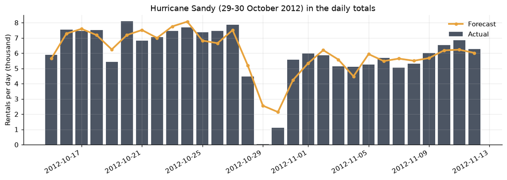

```python
fig, ax = plt.subplots(figsize=(10.5, 3.8))
span = daily_err.loc["2012-10-15":"2012-11-12"]
ax.bar(span.index, span.actual / 1000, color="#2d3748", width=0.8, label="Actual", alpha=0.85)
ax.plot(span.index, span.forecast / 1000, color=AMBER, lw=2.5, marker="o", ms=4, label="Forecast")
ax.set_ylabel("Rentals per day (thousand)")
ax.set_title("Hurricane Sandy (29-30 October 2012) in the daily totals")
ax.legend(frameon=False)
fig.autofmt_xdate()
fig.tight_layout()
plt.show()
```

## 7. What does the model rely on?

**Permutation importance** shuffles one feature at a time on the unseen months and measures how much the error grows. A feature that makes no difference when scrambled was not being used.

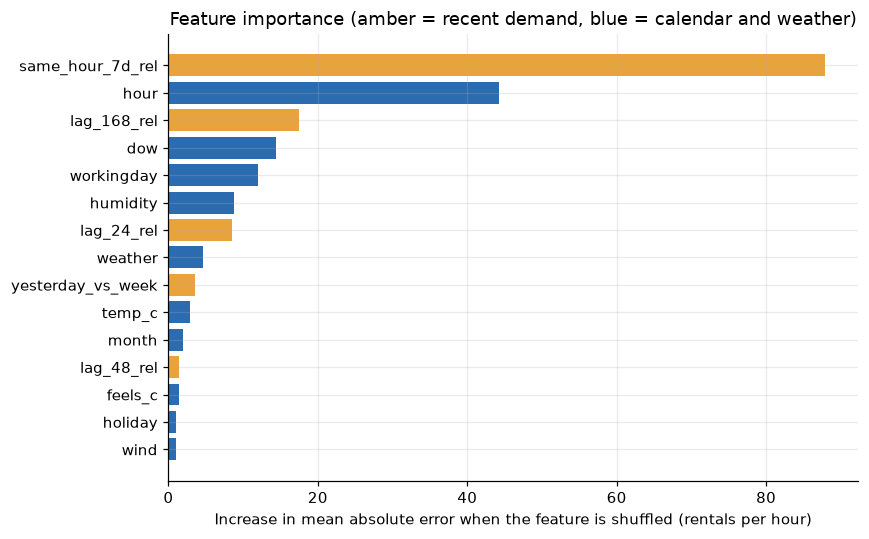

|  | extra error |
| --- | --- |
| same_hour_7d_rel | 87.9 |
| hour | 44.2 |
| lag_168_rel | 17.4 |
| dow | 14.3 |
| workingday | 12.0 |

```python
# done by hand because the model predicts a relative quantity: shuffle one column, predict, multiply back, measure the error in rentals
rng = np.random.default_rng(0)
base_error = np.abs(y_test - model_rel.predict(rel_test) * scale_test.to_numpy()).mean()
rows = {}
for col in rel_test.columns:
    extra = []
    for _ in range(5):
        shuffled = rel_test.copy()
        shuffled[col] = rng.permutation(shuffled[col].to_numpy())
        extra.append(np.abs(y_test - model_rel.predict(shuffled) * scale_test.to_numpy()).mean() - base_error)
    rows[col] = np.mean(extra)
importance = pd.Series(rows).sort_values()
recent = [c for c in importance.index if c.endswith("_rel") or c == "yesterday_vs_week"]
fig, ax = plt.subplots(figsize=(8, 5))
ax.barh(importance.index, importance.values, color=[AMBER if f in recent else BLUE for f in importance.index])
ax.set_xlabel("Increase in mean absolute error when the feature is shuffled (rentals per hour)")
ax.set_title("Feature importance (amber = recent demand, blue = calendar and weather)")
fig.tight_layout()
plt.show()
importance.sort_values(ascending=False).head(5).round(1).to_frame("extra error")
```

## What the results say

- **Demand has a strong rhythm.** On working days there are two commuter peaks, at 8 a.m. (about 475 rentals an hour on average) and at 5 p.m. (about 525), while weekends have a single midday hump (about 370 around 1 p.m.). Warmth matters a lot: the average hour has about 47 rentals below 5 degrees and more than 300 at 30-35 degrees. Light rain or snow roughly halves demand (104 an hour against 204 on clear hours).
- **The system grew by 65%.** 1.24 million rentals in 2011 and 2.05 million in 2012, which is the main trap for a forecast: a model that learned the past has never seen autumn 2012 levels.
- **Simple baselines fail for different reasons.** On the 4,416 unseen hours from July to December 2012, "the same hour last week" misses 66 rentals an hour on average (26% of all demand). The weekday x hour average from the training years is much worse (107, 43%) because it forecasts a third too little: it cannot know the system has grown. Trees using only the calendar and the weather are just as biased (a mean error of 94 rentals and 34% too little demand).
- **Recent demand is the most valuable input, and how it is used matters.** Adding yesterday, last week and the past seven days to the trees brings the error down to 48.7 rentals an hour, but they still forecast 12% too little, because trees cannot predict above the levels they saw in training. Predicting demand *relative to the recent level* and multiplying back fixes that: the error falls to 38.3 rentals an hour (15.2% of demand), the overall bias to +0.1%, and the error is **42% lower than the last-week baseline**.
- **The forecast tracks the week well.** The plot of a September week shows the forecast following the morning and evening peaks and the weekend shape hour by hour, and most points sit inside the interval.
- **Raw prediction intervals were too narrow.** The 80% interval from quantile trees contained only 68.9% of the real values on unseen months. After conformal calibration (widening by the misses measured on validation months) the coverage on the test months is **80.0%**, at the cost of an average width of 128 rentals instead of 108. A forecast that claims 80% and delivers 69% is worse than useless for planning.
- **What the model relies on.** Shuffling the average demand of the same hour over the past seven days (relative to the recent level) raises the error by 88 rentals an hour, the hour of the day by 44, the same hour last week by 17, the weekday by 14 and the working-day flag by 12. Weather features matter far less once recent demand is known, because last week's demand already contains the season and the temperature.
- **The errors sit where the demand is.** Mean absolute error is below 20 rentals at night and around 70 at 8 a.m. and 77 at 5-6 p.m., where the baseline misses 124 and 150. The model roughly halves the baseline's error at both peaks.
- **Holidays and a hurricane are the real failures.** On the six public holidays in the test period the model misses 29% of the day's demand, against 15% on ordinary days. Thanksgiving (22 November) was forecast at 4,495 rentals and was 2,425; 4 July was forecast at 6,277 and was 7,403. During Hurricane Sandy, demand fell to 22 rentals on 29 October and 1,096 on the 30th. The forecast dipped (to about 2,600 and 2,100) because of the rain and the lower recent demand, but nothing in the data could tell it the system would nearly stop.

**Limits:** the weather in the features is the actual weather, standing in for a forecast, so real-life results would be a little worse; this is one city over two years and one hurricane; with only six holidays in the test period the holiday result is indicative, not precise; hours missing from the source were treated as zero rentals.

**Techniques covered:** time-based train, validation and test split, lag features that never use the forecast day, gradient boosting with a Poisson loss, a scale-free target, quantile regression with conformal calibration, MAE, RMSE, WAPE and bias, permutation importance by hand, and error analysis by hour of day, holiday and event.